# Report Exercise Chapter 9

Emma Biland

2025-05-20

## 1. Evaluation of all bivariate models

We start by fitting all simple linear models with GPP as the response and each predictor alone.

```r
predictors <- setdiff(names(df), "GPP_NT_VUT_REF")

bivariate_models <- purrr::map_dfr(predictors, function(var) {
  model <- lm(paste("GPP_NT_VUT_REF ~", var), data = df)
  tibble::tibble(
    predictor = var,
    r_squared = summary(model)$r.squared
  )
}) %>%
  dplyr::arrange(desc(r_squared))

knitr::kable(bivariate_models, digits = 3, caption = "R² values for all bivariate models")
```

R² values for all bivariate models

| predictor | r_squared |
| --- | --- |
| PPFD_IN | 0.452 |
| SW_IN_F | 0.431 |
| SW_IN_F_MDS | 0.430 |
| TA_F_MDS | 0.387 |
| TA_F | 0.387 |
| VPD_F | 0.191 |
| VPD_F_MDS | 0.181 |
| LW_IN_F | 0.168 |
| LW_IN_F_MDS | 0.121 |
| siteid | 0.046 |
| CO2_F_MDS | 0.030 |
| WS_F | 0.008 |
| TIMESTAMP | 0.005 |
| P_F | 0.002 |
| PA_F | 0.000 |
| USTAR | 0.000 |

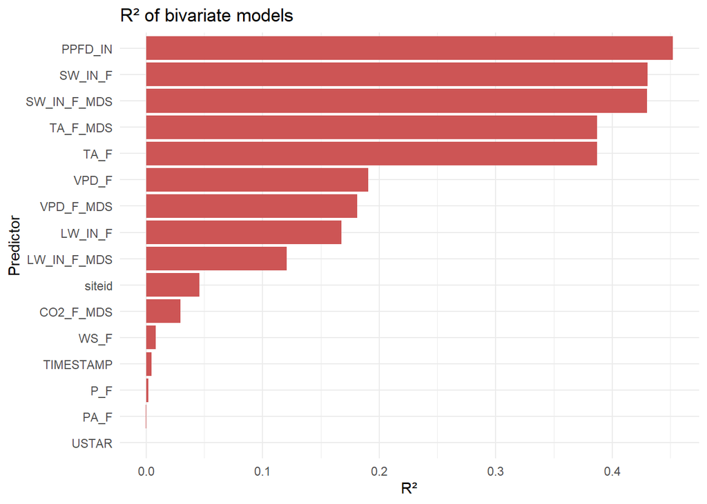

```r
ggplot2::ggplot(bivariate_models, ggplot2::aes(x = reorder(predictor, r_squared), y = r_squared)) +
  ggplot2::geom_col(fill = "indianred3") +
  ggplot2::coord_flip() +
  ggplot2::labs(title = "R² of bivariate models", x = "Predictor", y = "R²") +
  ggplot2::theme_minimal()
```

The strongest bivariate relationship with GPP is observed for `PPFD_IN` (R² = 0.452), highlighting the importance of light availability. Several other predictors, such as `PA_F` or `USTAR`, have negligible explanatory power, confirming that not all environmental variables directly affect GPP in a linear fashion.

## 2. Stepwise forward selection using R²

We implement a custom algorithm that starts with the best univariate model and iteratively adds the variable that improves R² the most.

```r
stepwise_forward_r2 <- function(data, response, predictors) {
  remaining <- predictors
  selected <- c()
  current_r2 <- 0
  steps <- list()

  while (length(remaining) > 0) {
    r2_results <- purrr::map_dfr(remaining, function(var) {
      formula <- as.formula(paste(response, "~", paste(c(selected, var), collapse = " + ")))
      model <- lm(formula, data = data)
      tibble::tibble(var = var, r_squared = summary(model)$r.squared)
    })

    best <- r2_results %>% dplyr::arrange(desc(r_squared)) %>% dplyr::slice(1)

    if (best$r_squared > current_r2 + 0.01) {
      selected <- c(selected, best$var)
      remaining <- setdiff(remaining, best$var)
      current_r2 <- best$r_squared
      steps[[length(steps) + 1]] <- list(vars = selected, r2 = current_r2)
    } else {
      break
    }
  }

  tibble::tibble(step = seq_along(steps),
                 predictors = purrr::map_chr(steps, ~ paste(.x$vars, collapse = " + ")),
                 r_squared = purrr::map_dbl(steps, ~ .x$r2))
}
```

```r
stepwise_results <- stepwise_forward_r2(df, "GPP_NT_VUT_REF", predictors)
knitr::kable(stepwise_results, caption = "Stepwise forward selection steps (R²)")
```

Stepwise forward selection steps (R²)

| step | predictors | r_squared |
| --- | --- | --- |
| 1 | PPFD_IN | 0.4520702 |
| 2 | PPFD_IN + LW_IN_F | 0.5301754 |
| 3 | PPFD_IN + LW_IN_F + siteid | 0.5981762 |
| 4 | PPFD_IN + LW_IN_F + siteid + VPD_F | 0.6160337 |
| 5 | PPFD_IN + LW_IN_F + siteid + VPD_F + TA_F_MDS | 0.6454925 |

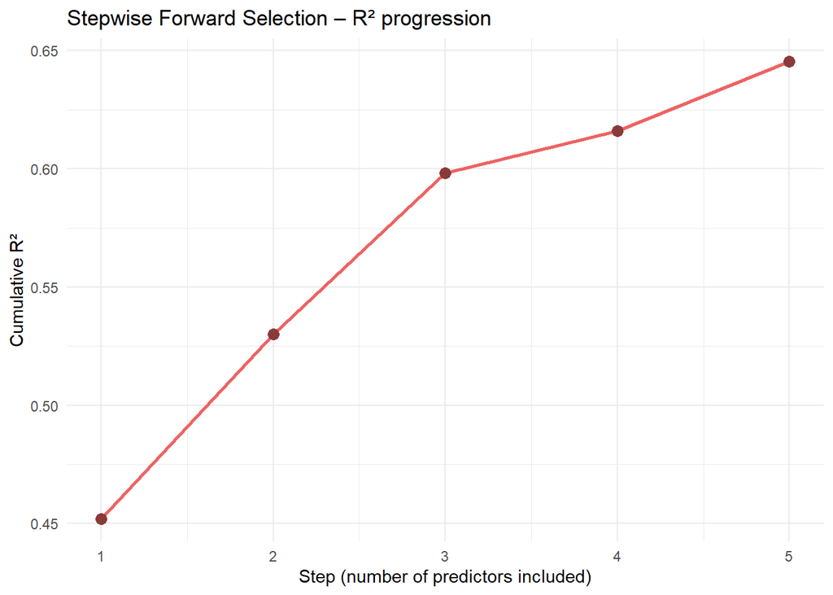

```r
ggplot2::ggplot(stepwise_results, ggplot2::aes(x = step, y = r_squared)) +
  ggplot2::geom_line(color = "indianred2", linewidth = 1) +
  ggplot2::geom_point(color = "indianred4", size = 3) +
  ggplot2::labs(
    title = "Stepwise Forward Selection – R² progression",
    x = "Step (number of predictors included)",
    y = "Cumulative R²"
  ) +
  ggplot2::theme_minimal()
```

The plot shows a rapid initial increase in R², especially after adding the first predictor `PPFD_IN` Additional variables improve the model more moderately. The process stops automatically when no remaining variable improves R² by more than 0.01. This illustrates how stepwise selection identifies a compact subset of informative predictors.

## 3. Final model diagnostics

```r
final_formula <- as.formula(paste("GPP_NT_VUT_REF ~", stepwise_results$predictors[nrow(stepwise_results)]))
final_model <- lm(final_formula, data = df)

summary(final_model)
```

```
##
## Call:
## lm(formula = final_formula, data = df)
##
## Residuals:
##     Min      1Q  Median      3Q     Max
## -8.5934 -1.1937 -0.0297  1.2241 11.4455
##
## Coefficients:
##                Estimate Std. Error t value Pr(>|t|)
## (Intercept)  -1.0877558  0.1863600  -5.837 5.42e-09 ***
## PPFD_IN       0.0109585  0.0001409  77.756  < 2e-16 ***
## LW_IN_F       0.0043039  0.0006439   6.684 2.40e-11 ***
## siteidCH-Lae  1.2555437  0.0500412  25.090  < 2e-16 ***
## siteidFI-Hyy  0.7127789  0.0469323  15.187  < 2e-16 ***
## siteidFR-Pue -1.0831129  0.0532717 -20.332  < 2e-16 ***
## VPD_F        -0.3058781  0.0072778 -42.029  < 2e-16 ***
## TA_F_MDS      0.1808290  0.0048302  37.437  < 2e-16 ***
## ---
## Signif. codes:  0 '***' 0.001 '**' 0.01 '*' 0.05 '.' 0.1 ' ' 1
##
## Residual standard error: 1.939 on 16866 degrees of freedom
##   (3711 observations effacées parce que manquantes)
## Multiple R-squared:  0.6455, Adjusted R-squared:  0.6453
## F-statistic:  4387 on 7 and 16866 DF,  p-value: < 2.2e-16
```

## 4. Interpretation

The stepwise selection process retained the following predictors:

- PPFD_IN + LW_IN_F + siteid + VPD_F + TA_F_MDS

The model explains 64.5% of the variance in GPP, which is substantial. The first variable added (according to the bivariate R² values) likely had the strongest relationship with GPP. Additional variables added smaller improvements, with a +0.01 R² gain threshold required to include them. Some variables with high bivariate R², such as `SW_IN_F`, were not included in the final model. This may be due to their strong correlation with already selected predictors (e.g., `PPFD_IN`), which capture overlapping variance. Other variables, such as `PA_F`, `P_F`, or `USTAR`, were excluded because they contributed little explanatory power, either due to weak relationships with GPP or high noise.

This simplified forward selection gives insight into which environmental factors most influence GPP under the conditions measured.